# TRIANGULAR ARBITRAGE IN NIGERIAN BDC MARKET

## THE CASE OF GBP-USD-NGN

This notebook investigates the availability of triangular arbitrgae opportunities in Nigerian Bureau de Chnage markets. It specifically focus on the case of GBP-USD-NGN. In this case, a triangular arbitrage opportunity exists when the amount of Naira gotten from the indirect (3-way, 2-step) exchange of GBP to USD to NGN exceeds the direct (2-way, 1-step).

### JOHN'S DILEMMA

For practical purposes, a hypothetical real life example illustrates the case: John has a special passport that allows him to bypass travel restrictions and thus, travel from UK to Nigeria during the COVID-19 pandemic. He has already paid for his flight so we will ignore those costs. John has GBP notes and wants to change it to NGN. He has two choices:

1. Change it to Naira directly
2. Change it to Dollar in then change the Dollar to Naira i.e indirect change

If a triangular arbitrage opportunity does exist then John gets more money in the second scenario as opposed to the first. It is typically very difficult to find these opportunities and even more difficult to execute.

## WHY DOES THIS EXIST OR NOT EXIST?

### CAUSES AND FRICTIONS

It is diffucult to find because BDCs will buy a currency from you at a rate lower than which they will sell. This is how they make their profit. Let's call this a 'market friction'. Thus, executing a 2-step (3-way, indirect) exchange whould cost more as there are two levels (as opposed to one level) of this market friciton. But in times like this (i.e COVID-19 pandemic), the rush towards the Dollar (safe haven currency) as opposed to the Pound coupled with restrictions on exchanging currency at banks can create some discrepancies between the global GBP/USD exchange rate and the implied local GBP/USD exchange rate which allows some profit to be made in the process.

### EXECUTION DIFFICULTIES

It is difficult to execute because there is some logistics involved i.e no one (that I am aware of) has this 'special' passport. There are several alternatives to travelling if John is already in Nigeria. He just needs to find a way of changing his GBP to USD at the official global rate (ordinarily, if he does so in Nigeria he will do so at the implied BDC rate which will neutralise the profit potential). John could:

1. Have a 'special' bank account that allows him to deposit any currency and withdraw internationally in the currency of his choice (GBP or USD) i.e. deposit his GBP --> withdraw in USD (will be done at official global rate) --> chnage to Naira at BDC
2. Could meet someone in Nigeria with USD willing and to do the GBP to USD exchange at the global official rate i.e. exchange GBP for USD at global official rate --> change USD to GBP at local BDC rate
3. Some other means of converting GBP to USD at the global officialexchange rate

## JUST WANT TO MAKE A PROFIT?

What if John has no use for Naira now and just wants to make a profit in GBP from this opportunity? John could add an extra step of changing his NGN to GBP and realising a profit (if one exists). This can be donw by depotiting the NGN in the special bank account in (1) above The steps will now be:

1. John has GBP
2. John changes GBP to USD in UK
3. John changes USD to NGN in a Nigerian BDC
4. John changes NGN to GBP in a Nigerian BDC
5. ASSUMING HE HAS THE 'SPECiAL' bank account: deposit the NGN in the account and withdraw in GBP
6. At this point he should have more GBP than he started with if the triangular arbitrage existed

## GUIDE TO NOTEBOOK

The Notebook that follows illustrates a method for detecting and measuring the profitablity of this arbitrage. It uses data from abokiFX.com to get NGN BDC rates (for USD/NGN and GBP/NGN) and from Yahoo finance to get the global GBP/USD rate. The steps are as follows:

1. Scrape abokiFX.com for USD/NGN and GBP/NGN local BDC rates
2. Prepare the data for use in the sections to follow
3. Get GBP/USD rate from Yahoo finance
4. Calculate potential profits from the triangular arbitrage

Each section will be headed according to the steps listed above. The accompanying code will follow. If the reader is not interested in the code, he/she may skip to the last section (4) near the bottom of the notebook.

## 1) Scrape abokiFX.com for USD/NGN and GBP/NGN local BDC rates

In the following code-blocks, I scrape abokiFx.com for USD/NGN and GBP/NGN rates. This is done using the webscraping module: BeautifulSoup aka bs4. We use this to extract the DOM (HTML representative of the site) and get the values we want out of it.

```python
#Python program to scrape website
#and save quotes from website
import requests
from bs4 import BeautifulSoup

#GET HTML DOM contents
URL = "https://www.abokifx.com/home_bdc_rate" #URL for getting BDC rates from abokiFX.com
r = requests.get(URL) #response to the HTTP request on the abokiFX site
soup = BeautifulSoup(r.content, 'html5lib') #'soupify' for traversal using bs4
```

```python
quotes=[] # a temporary list to store all exchange rate quotes
body = soup.find('table', attrs = {'class':'grid-table'}) #find the relveant data table by it's classname
rates = body.findAll('td') #get the rates from the table by copying all 'td' tags


#EXTRACT THE TEXT FROM THE 'TD' TAG CONTENTS
for rate in rates:
    #print(rate.text)#print the extracted text to verify it is correct
    quotes.append(rate.text)#append the text to a list
```

## 2) Prepare the data for use in the sections to follow

There is significant cleaning and formatting of the rates data to put it in a format amenable for our analysis. This includes: separating the rates in to USD/NGN and USD/GBP, separating buying and selling rates, aligning the data chronologically, etc. This is done in the code-blcks below:

```python
#CREATE EMPTY LISTS AS CONTAINERS FOR DATES, USD RATES, GBP RATES, EUR RATES (NOT USED IN THIS EXAMPLE)
dates = []
usd = []
gbp = []
eur = []

#TRAVERSE THE 'QUOTES' LIST, EXTRACT THE RATES AND ADD TO THEIR DEDICATED LISTS
#values come in fours - date, usd, gbp, eur - thus us i mod 4 to get skip through irrelavant values for each currency
for i in range(len(quotes)):
    if i%4 == 0: #every 1st out of 4 consecutive values starting from 0 is a date
        dates.append(quotes[i]) #add to dates list
    elif i%4 == 1: #every 1st out of 4 consecutive values starting from 0 is a usd rate
        usd.append(quotes[i]) #add to usd list
    elif i%4 == 2: #every 1st out of 4 consecutive values starting from 0 is a gbp rate
        gbp.append(quotes[i]) #add to gbp list
    elif i%4 == 3: #every 1st out of 4 consecutive values starting from 0 is an eur date
        eur.append(quotes[i]) #add to eur list
#EXTRACT ONLY THE 1st 15 QUOTES
dates = dates[0:15]
usd = usd[0:15]
gbp = gbp[0:15]
eur = eur[0:15]

for i in range(len(dates)):
    print('{}  {}  {}  {}'.format(dates[i], usd[i], gbp[i], eur[i]))
```

```
30/04/20  430 / 450  490 / 500  425 / 450
29/04/20  430 / 462  490 / 520  435 / 460
28/04/20  430 / 462  485 / 514  430 / 455
27/04/20  430 / 450  485 / 505  430 / 450
26/04/20  370 / 380  480 / 490  405 / 415
24/04/20  370 / 380  480 / 490  405 / 415
23/04/20  370 / 380  480 / 490  405 / 415
22/04/20  370 / 380  480 / 490  405 / 415
21/04/20  370 / 380  480 / 490  405 / 415
20/04/20  370 / 380  480 / 490  405 / 415
18/04/20  370 / 380  480 / 490  405 / 415
17/04/20  370 / 380  480 / 490  405 / 415
16/04/20  370 / 380  480 / 490  405 / 415
15/04/20  370 / 380  480 / 490  405 / 415
14/04/20  370 / 380  480 / 490  405 / 415
```

```python
#SEPARATE RATES INTO BUY AND SELL

#CREATE EMPTY LISTS AS CONTAINERS FOR BUY NAD SELL RATES FOR EACH CURRENCY
usd_buy = []#rate at which BDC buys (you sell) USD
gbp_buy = []
eur_buy = []

usd_sell = []#rate at which BDC sells (you buy) USD
gbp_sell = []
eur_sell = []

#traverse the vales and separate into buy or sell rates
#first 4 cars - buy rates
#last 4 chars - sell rates
for i in range(len(dates)):
    date = dates[0]
    usd_buy.append(float(usd[i][:3]))
    gbp_buy.append(float(gbp[i][:3]))
    eur_buy.append(float(eur[i][:3]))

    usd_sell.append(float(usd[i][6:]))
    gbp_sell.append(float(gbp[i][6:]))
    eur_sell.append(float(eur[i][6:]))
```

```python
#REVERSE THE LISTS TO THAT THE VALUES FOLLOW CHRONOLOGICAL ORDER
dates.reverse()
usd_buy.reverse()
gbp_buy.reverse()
eur_buy.reverse()

usd_sell.reverse()
gbp_sell.reverse()
eur_sell.reverse()

print(usd_buy)
print(usd_sell)
```

```
[370.0, 370.0, 370.0, 370.0, 370.0, 370.0, 370.0, 370.0, 370.0, 370.0, 370.0, 430.0, 430.0, 430.0, 430.0]
[380.0, 380.0, 380.0, 380.0, 380.0, 380.0, 380.0, 380.0, 380.0, 380.0, 380.0, 450.0, 462.0, 462.0, 450.0]
```

## 3) Get global GBP/USD rate from Yahoo finance

In the following code-blocks, I retrieve the values of global GBP/USD rates for the last 15 days from Yahoo finance. I used the pandas_datareader module which has an API (direct manes of access) to the Yahoo Finance database.

```python
from pandas_datareader import data
import numpy as np
import matplotlib.pyplot as plt
import pandas as pd

today = '2020-4-30'

# Only get the adjusted close.
gbp_to_usd = data.DataReader("GBPUSD=X", start='2020-3-25', end= today, data_source='yahoo')['Open']
```

```python
gbp_to_usd = gbp_to_usd[-15:]
print(gbp_to_usd)
print(len(gbp_to_usd))
```

```
Date
2020-04-09    1.245982
2020-04-12    1.245904
2020-04-13    1.252035
2020-04-14    1.262403
2020-04-15    1.252191
2020-04-16    1.248782
2020-04-19    1.248751
2020-04-20    1.244245
2020-04-21    1.230239
2020-04-22    1.232256
2020-04-23    1.235315
2020-04-26    1.236858
2020-04-27    1.242236
2020-04-28    1.243394
2020-04-30    1.242498
Name: Open, dtype: float64
15
```

## 4) Calculate potential profits from the triangular arbitrage

In this section, I calculate the percentage profit (returns) from the triangular arbitrade if executed on each of the last 15 days at the rates corresponding to those days. Note: If an efficient means of making the exchanges at both global rates (for GBP to USD) and local rates (for USD to NGN and NGN to USD), the executor could possibly execute this trade several times in a single day and thus, increase the daily profit potential.

```python
#define the arbitrage opportunity
returns = []
amount_in_gbp = 1000
for i in range(len(dates)):
    amount_in_usd = amount_in_gbp * gbp_to_usd[i] #change GBP to USD
    amount_in_naira = usd_buy[i] * amount_in_usd #change USD to NGN
    new_gbp_value = float(amount_in_naira)/gbp_sell[i] #change NGN to GBP
    profit = new_gbp_value - amount_in_gbp #calculate profit i.e. final - initial
    percentage_profit = (profit/amount_in_gbp)*100 #calculate percentage profit i.e. profit/initial
    print('return at {} is {}%'.format(dates[i], percentage_profit))
    returns.append(percentage_profit)
```

```
return at 14/04/20 is -5.915668059368522%
return at 15/04/20 is -5.9215280474448715%
return at 16/04/20 is -5.458615993966862%
return at 17/04/20 is -4.675681980288755%
return at 18/04/20 is -5.446778998082993%
return at 20/04/20 is -5.704186400588674%
return at 21/04/20 is -5.706544798247671%
return at 22/04/20 is -6.046775165869269%
return at 23/04/20 is -7.104381493159702%
return at 24/04/20 is -6.952129821388087%
return at 26/04/20 is -6.721096865984862%
return at 27/04/20 is 5.316653110013158%
return at 28/04/20 is 3.9224684470358624%
return at 29/04/20 is 2.8191600854580203%
return at 30/04/20 is 6.854862213134766%
```

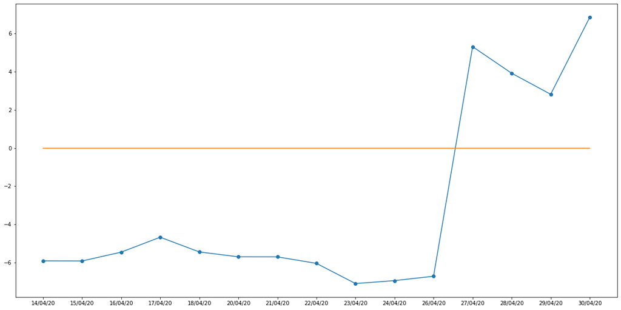

```python
import matplotlib.pyplot as plt
%matplotlib inline
plt.figure(figsize= (20,10))

plt.scatter(dates,returns)
plt.plot(returns)
plt.plot(range(len(returns)),np.zeros(len(returns)))
```

# CONCLUSION

The graph above shows that for the last four days, an arbitrage opportunity has existed. This can be exploited by anyone who is able to bypass the logistical constraint (e.g. has the 'special' bank account) and has enough money to dedicate to the trade. As mentioned earlier, he/she could possibly execute this trade many times in a day if the logistics are efficient. If executed 8 timess in a day (once every working hour), the average 4% will become (($1.04^8$ - 1) * 100 = 36% returns in a single day. How's that for alchemy.

It also shows that this opportunity did not exist in the 11 days prior. In fact there is a loss associated with the trade. This is due to the'market friction' referenced in the introduction (i.e BDC operators sell currency at a higher price than they buy it in order to make a profit).

Attempting to forecast how long such an opportunity will remain is most likely an exercise in vain. It will depend on largely unpredictable global macroeconomic factors (due to the COVID-19 pandemic's effect on global markets and CBN policy on buying currency) and also on local microeconimic factors (Other Arbitrageurs may wipe away this opportunity by taking advantage of it i.e. supply and demand will reach equilibrium). One could also utilise data from the last time such an opportunity arose (e.g 2015 currency devaluation and consequent CBN restrictions) to detect patterns that may be indicative of the timeline of this opportunity. But it is likely that the sample set will be too specific to that time to draw meaningful conclusions. Could be fun to try anyways. An attempt to forecast it may be done in another notebook but don't hold your breath.

While arbitrage by definition is riskless, it should be noted that there are limitations for the results of this notebook:

1. Exchange actually change in real-time. In this notebook, I have used a singular (opening price) rate for each day.
2. In this notebook, while buying and selling price discrpancy is accounted for in the BDC rates (GBP to USD and USD to NGN) it is ignored in the GBP/USD rate (the discrepancy is usually much smaller)
3. Speed of execution is a factor in arbitrage as rates change in real-time
4. I have relied on the data in AbokiFX.com which may or may not be trade-able depending on if you can find the BDC operator who provides the quotes (Should be very possible)
5. If you can think of other reasons I might be missing out (most likely exist), please contact me on LinkedIn: Olaoluwapo Oyefolu, or comment (if on blog).

## BONUS

I just noticed that in the interval of 7 to 13, ($1.04^x$ -1) * 100 resembles an arithmetic progrssion with a difference of 5.6

```python
#SIMULATE BOTH THE ACTUAL GEOMETRIC PROGRESSION AND ARTIHMETIC APPROXIMATION IN THE INTERVAL
actual = []
arithmetic = []
sixth = (((1.04**6)-1)*100)

for i in (range(6,14)):
    actual.append((((1.04**i)-1)*100))
    arithmetic.append(sixth + (i-6)*5.6)
for i in range(len(actual)):
    print(i+6, actual[i] - arithmetic[i])
```

```
6 0.0
7 -0.5387239260160079
8 -0.8749968090726483
9 -1.0007206074515338
10 -0.9074733577656033
11 -0.5864962180922078
12 -0.028679992831875722
13 0.775448881438848
```

The plot below illustrates their closeness. Note: this relationship no longer holds past this limit. Perhas some other does, idk.

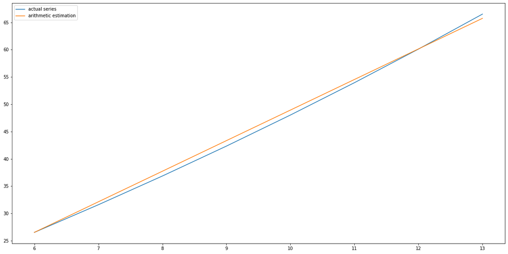

```python
plt.figure(figsize = (20,10))
plt.plot(range(6,14),(actual))
plt.plot(range(6,14),arithmetic)
plt.legend(['actual series','arithmetic estimation'])
```